# Chapter 28: Graphics for communication

```r
library(tidyverse)
```

# 28.2 Label

## 28.2.1 Exercises

1. Create one plot on the fuel economy data with customised `title`, `subtitle`, `caption`, `x`, `y`, and `colour` labels.

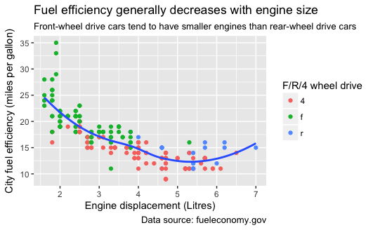

```r
mpg %>%
  ggplot(aes(displ, cty)) +
    geom_point(aes(colour = drv)) +
    geom_smooth(se = FALSE) +
    labs(
      title = "Fuel efficiency generally decreases with engine size",
      subtitle = "Front-wheel drive cars tend to have smaller engines than rear-wheel drive cars",
      caption = "Data source: fueleconomy.gov",
      x = "Engine displacement (Litres)",
      y = "City fuel efficiency (miles per gallon)",
      colour = "F/R/4 wheel drive"
    )
```

2. The `geom_smooth()` is somewhat misleading because the `hwy` for large engines is skewed upwards due to the inclusion of lightweight sports cars with big engines. Use your modelling tools to fit and display a better model.

**Let’s begin by fitting a linear model to the data using only engine displacement.**

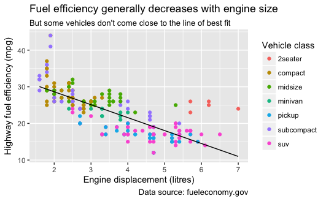

```r
library(modelr)
library(ggbeeswarm)
mod1 <- lm(hwy ~ displ, data = mpg)
mpg1 <- add_predictions(mpg, mod1)
mpg1 <- add_residuals(mpg1, mod1)
ggplot(mpg1, aes(displ, hwy)) +
  geom_point(aes(colour = class)) +
  geom_line(aes(y = pred)) +
  labs(
    title = "Fuel efficiency generally decreases with engine size",
    subtitle = "But some vehicles don't come close to the line of best fit",
    caption = "Data source: fueleconomy.gov",
    x = "Engine displacement (litres)",
    y = "Highway fuel efficiency (mpg)",
    colour = "Vehicle class"
  )
```

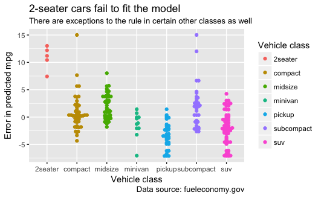

```r
ggplot(mpg1, aes(class, resid)) +
  geom_beeswarm(aes(colour = class)) +
  labs(
    title = "2-seater cars fail to fit the model",
    subtitle = "There are exceptions to the rule in certain other classes as well",
    caption = "Data source: fueleconomy.gov",
    x = "Vehicle class",
    y = "Error in predicted mpg",
    colour = "Vehicle class"
  )
```

**We can see that there are elevated residuals for all vehicles in the 2-seater class, along with some outliers among the subcompact class (among others). Let’s fit a second model that includes class as well as engine displacement.**

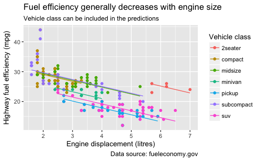

```r
mod2 <- lm(hwy ~ displ + class, data = mpg)
mpg2 <- add_predictions(mpg, mod2)
mpg2 <- add_residuals(mpg2, mod2)
ggplot(mpg2, aes(displ, hwy, colour = class)) +
  geom_point() +
  geom_line(aes(y = pred)) +
  labs(
    title = "Fuel efficiency generally decreases with engine size",
    subtitle = "Vehicle class can be included in the predictions",
    caption = "Data source: fueleconomy.gov",
    x = "Engine displacement (litres)",
    y = "Highway fuel efficiency (mpg)",
    colour = "Vehicle class"
  )
```

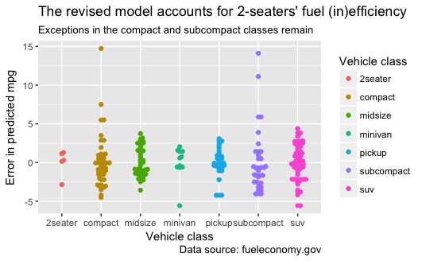

```r
ggplot(mpg2, aes(class, resid)) +
  geom_beeswarm(aes(colour = class)) +
  labs(
    title = "The revised model accounts for 2-seaters' fuel (in)efficiency",
    subtitle = "Exceptions in the compact and subcompact classes remain",
    caption = "Data source: fueleconomy.gov",
    x = "Vehicle class",
    y = "Error in predicted mpg",
    colour = "Vehicle class"
  )
```

**This model works much better for addressing the 2-seater vehicles. Note that we could have used an interaction between displacement and class - I tested this out but the result doesn’t seem much improved over this model. Also note that there are still some vehicles among the compact and subcompact classes that the model doesn’t do a good job of fitting, which could warrant further investigation.**

3. Take an exploratory graphic that you’ve created in the last month, and add informative titles to make it easier for others to understand.

**This is something I’ll come back to as I work on other projects after working through this book.**

# 28.3 Annotations

## 28.3.1 Exercises

1. Use `geom_text()` with infinite positions to place text at the four corners of the plot.

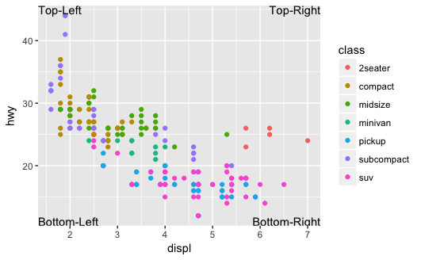

```r
labels <- tibble(
  x = c(-Inf, -Inf, Inf, Inf),
  y = c(Inf, -Inf, Inf, -Inf),
  lab = c("Top-Left", "Bottom-Left", "Top-Right", "Bottom-Right"),
  v = c("top", "bottom", "top", "bottom"),
  h = c("left", "left", "right", "right")
)
ggplot(data = mpg, aes(displ, hwy)) +
  geom_point(aes(colour = class)) +
  geom_text(aes(x = x, y = y, label = lab, vjust = v, hjust = h), data = labels)
```

2. Read the documentation for `annotate()`. How can you use it to add a text label to a plot without having to create a tibble?

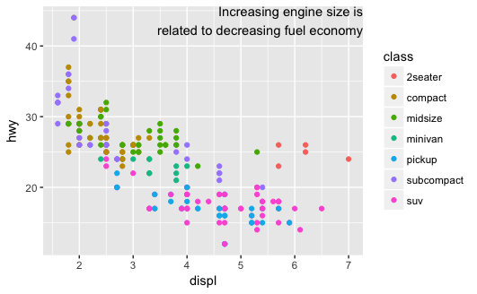

```r
?annotate
ggplot(data = mpg, aes(displ, hwy)) +
  geom_point(aes(colour = class)) +
  annotate(
    "text",
    label = "Increasing engine size is\nrelated to decreasing fuel economy",
    x = Inf,
    y = Inf,
    vjust = "top",
    hjust = "right"
  )
```

3. How do labels with `geom_text()` interact with faceting? How can you add a label to a single facet? How can you put a different label in each facet? (Hint: think about the underlying data.)

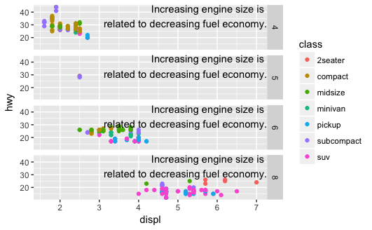

```r
label <- tibble(
  displ = Inf,
  hwy = Inf,
  label = "Increasing engine size is \nrelated to decreasing fuel economy."
)
ggplot(data = mpg, aes(displ, hwy)) +
  geom_point(aes(colour = class)) +
  geom_text(aes(label = label), data = label, vjust = "top", hjust = "right") +
  facet_grid( cyl ~ . )
```

**By default the single label will appear on each facet’s plot. To get a different label on each plot we need to set up the labels so they will correspond to the variable(s) by which we’re faceting.**

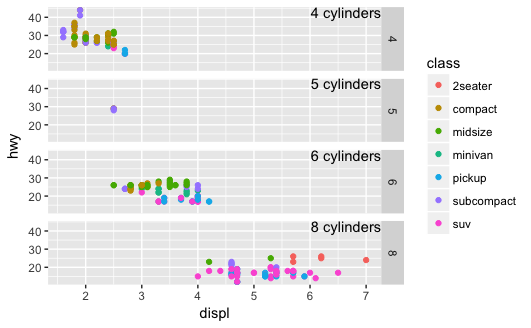

```r
facet_labels <- tibble(
  cyl = c(4, 5, 6, 8),
  displ = Inf,
  hwy = Inf,
  label = c("4 cylinders", "5 cylinders", "6 cylinders", "8 cylinders")
)
ggplot(data = mpg, aes(displ, hwy)) +
  geom_point(aes(colour = class)) +
  geom_text(aes(label = label), data = facet_labels, vjust = "top", hjust = "right") +
  facet_grid( cyl ~ . )
```

4. What arguments to `geom_label()` control the appearance of the background box?

```r
?geom_label
```

**`label.padding`, `label.r` and `label.size` control the padding, radius of corners and border size.**

5. What are the four arguments to `arrow()`? How do they work? Create a series of plots that demonstrate the most important options.

```r
?arrow
```

**The arguments are `angle` (angle/width of the arrow head - defaults to 30 degrees), `length` (of the arrow head - defaults to 0.25 inches), `ends` (which end/s of the line to draw the head on - “first”, “last”, or “both - defaults to”last“), and `type` (”open" or “closed” triangle - defaults to open).**

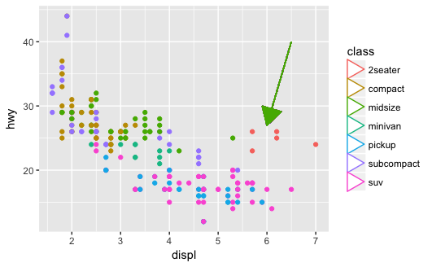

```r
ggplot(mpg, aes(displ, hwy, colour = class)) +
  geom_point() +
  geom_segment(
    aes(x = 6.5, y = 40, xend = 6, yend = 27),
    arrow = arrow(type = "closed")
  )
```

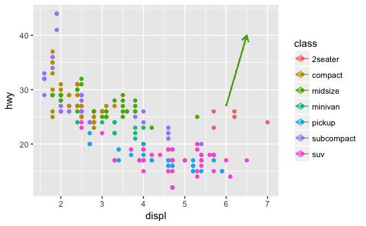

```r
ggplot(mpg, aes(displ, hwy, colour = class)) +
  geom_point() +
  geom_segment(
    aes(x = 6.5, y = 40, xend = 6, yend = 27),
    arrow = arrow(length = unit(0.1, "inches"), ends = "first")
  )
```

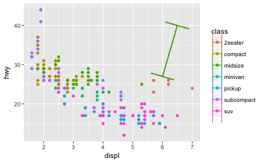

```r
ggplot(mpg, aes(displ, hwy, colour = class)) +
  geom_point() +
  geom_segment(
    aes(x = 6.5, y = 40, xend = 6, yend = 27),
    arrow = arrow(ends = "both", angle = 90)
  )
```

# 28.4 Scales

## 28.4.4 Exercises

1. Why doesn’t the following code override the default scale?

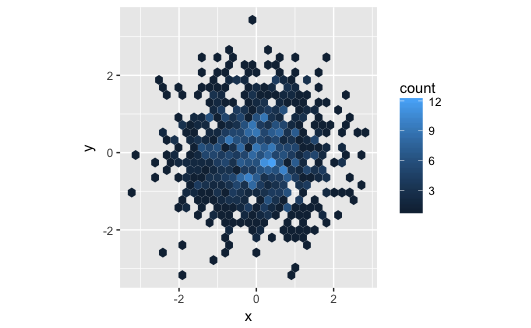

```r
# Create a sample data frame to run the code
df <- tibble(
  x = rnorm(1000),
  y = rnorm(1000)
)
ggplot(df, aes(x, y)) +
  geom_hex() +
  scale_colour_gradient(low = "white", high = "red") +
  coord_fixed()
```

**The `viridis` example just above the exercises used `scale_fill_viridis` rather than `scale_colour_viridis` - it looks like this code was targeting the wrong property.**

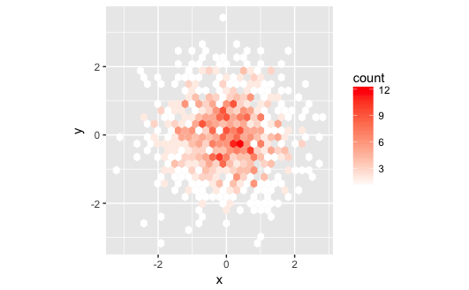

```r
ggplot(df, aes(x, y)) +
  geom_hex() +
  scale_fill_gradient(low = "white", high = "red") +
  coord_fixed()
```

2. What is the first argument to every scale? How does it compare to `labs()`?

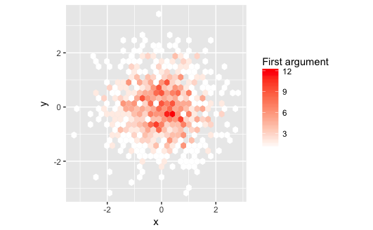

```r
ggplot(df, aes(x, y)) +
  geom_hex() +
  scale_fill_gradient("First argument", low = "white", high = "red") +
  coord_fixed()
```

**The first argument becomes the name/label of the scale.**

3. Change the display of the presidential terms by:
4. Combining the two variants shown above.
5. Improving the display of the y axis.
6. Labelling each term with the name of the president.
7. Adding informative plot labels.
8. Placing breaks every 4 years (this is trickier than it seems!).

**NB: I’ll make the improvements incremental where possible so that later plots have some of the features from the earlier ones.**

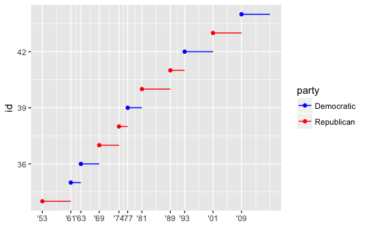

```r
presidential %>%
  mutate(id = 33 + row_number()) %>%
  ggplot(aes(start, id, colour = party)) +
    geom_point() +
    geom_segment(aes(xend = end, yend = id)) +
    scale_x_date(NULL, breaks = presidential$start, date_labels = "'%y") +
    scale_colour_manual(values = c(Republican = "red", Democratic = "blue"))
```

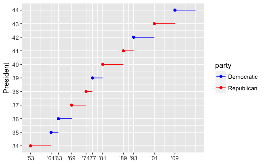

```r
# 2. Improving the display of the y axis
presidential %>%
  mutate(id = 33 + row_number()) %>%
  ggplot(aes(start, id, colour = party)) +
    geom_point() +
    geom_segment(aes(xend = end, yend = id)) +
    scale_x_date(NULL, breaks = presidential$start, date_labels = "'%y") +
    scale_y_continuous("President", breaks = seq(34, 44, by = 1)) +
    scale_colour_manual(values = c(Republican = "red", Democratic = "blue"))
```

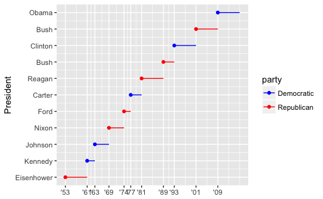

```r
# 3. Labelling each term with the name of the president.
presidential %>%
  mutate(id = 33 + row_number()) %>%
  ggplot(aes(start, id, colour = party)) +
    geom_point() +
    geom_segment(aes(xend = end, yend = id)) +
    scale_x_date(NULL, breaks = presidential$start, date_labels = "'%y") +
    scale_y_continuous("President", labels = presidential$name, breaks = seq(34, 44, by = 1)) +
    scale_colour_manual(values = c(Republican = "red", Democratic = "blue"))
```

**This replaces the number with the name, but means there are two Bushes not distinguished. Let’s try to get the name and number combined.**

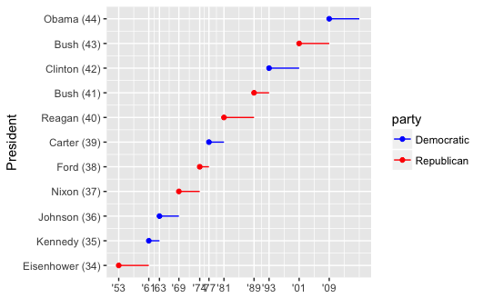

```r
library(stringr)
presidential %>%
  mutate(id = 33 + row_number()) %>%
  ggplot(aes(start, id, colour = party)) +
    geom_point() +
    geom_segment(aes(xend = end, yend = id)) +
    scale_x_date(NULL, breaks = presidential$start, date_labels = "'%y") +
    scale_y_continuous("President", labels = str_c(presidential$name, " (", seq(34, 44, by = 1), ")"), breaks = seq(34, 44, by = 1)) +
    scale_colour_manual(values = c(Republican = "red", Democratic = "blue"))
```

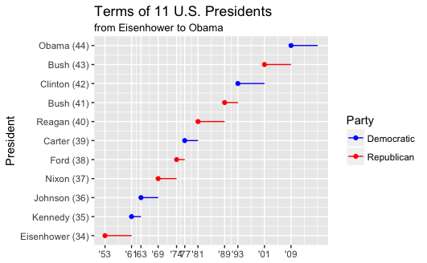

```r
# 4. Adding informative plot labels
presidential %>%
  mutate(id = 33 + row_number()) %>%
  ggplot(aes(start, id, colour = party)) +
    geom_point() +
    geom_segment(aes(xend = end, yend = id)) +
    scale_x_date(NULL, breaks = presidential$start, date_labels = "'%y") +
    scale_y_continuous("President", labels = str_c(presidential$name, " (", seq(34, 44, by = 1), ")"), breaks = seq(34, 44, by = 1)) +
    scale_colour_manual(values = c(Republican = "red", Democratic = "blue")) +
  labs(
    title = "Terms of 11 U.S. Presidents",
    subtitle = "from Eisenhower to Obama",
    colour = "Party"
  )
```

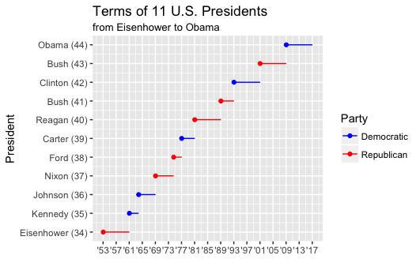

```r
# 5. Placing breaks every 4 years (this is trickier than it seems!)
library(lubridate)
presidential %>%
  mutate(id = 33 + row_number()) %>%
  ggplot(aes(start, id, colour = party)) +
    geom_point() +
    geom_segment(aes(xend = end, yend = id)) +
    scale_x_date(NULL, breaks = make_date(seq(min(year(presidential$start)), max(year(presidential$end)), by = 4)), date_labels = "'%y") +
    scale_y_continuous("President", labels = str_c(presidential$name, " (", seq(34, 44, by = 1), ")"), breaks = seq(34, 44, by = 1)) +
    scale_colour_manual(values = c(Republican = "red", Democratic = "blue")) +
  labs(
    title = "Terms of 11 U.S. Presidents",
    subtitle = "from Eisenhower to Obama",
    colour = "Party"
  )
```

4. Use `override.aes` to make the legend on the following plot easier to see.

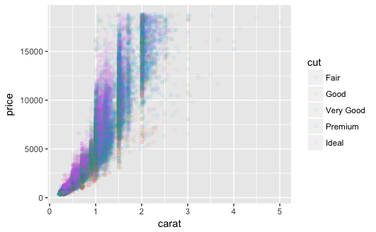

```r
ggplot(diamonds, aes(carat, price)) +
  geom_point(aes(colour = cut), alpha = 1/20)
```

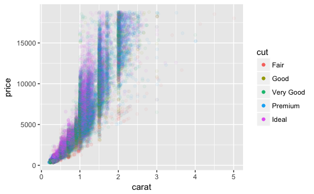

```r
ggplot(diamonds, aes(carat, price)) +
  geom_point(aes(colour = cut), alpha = 1/20) +
  guides(colour = guide_legend(override.aes = list(alpha = 1)))
```